# Correction and Interpretation of stable Carbon isotopes

#### COURSE: DISC, LTRR, UNIVERSITY OF ARIZONA. INSTRUCTORS: S. BELMECHERI & P. SZEJNER

### Instructions:

The following code and comments should further your experience to analyze and treat tree ring d13C data (including atmosphere and climate data). This exercise relies upon raw tree-ring d13C measurements, atmospheric d13C measurements, and instrumental climate data.

There are a few questions throughout to catalyze understanding and critical thinking. The analysis is broken into four main parts (including 17 questions). At the end, you should have gone through many of the steps commonly used for treating, correcting and, interpreting a d13C time series.

You will need to download the R project from https://github.com/SBelmecheri/DISCO-Notebook1.git and set your own working directory. Once you open the `DISCO-Notebook1.Rproj` in R studio you can open the `RNotebook1.Rmd` file to proceed with this exercise.

## PART 0: Setting up directories and files.

For the following exercise, you will need the following files in one directory:  
1. A file containing tree-ring d13C measurements. The filename is “LIL.txt”.  
2. A file containing atmospheric 13C data. The filename is “ATM13C.txt”.  
3. A file containing regional temperature data. The filename is “CRU_tt.txt”.  
4. A file containing regional precipitation data. The filename is “CRU_PP.txt”.  
4. A file containing regional Vapor pressure deficit data. The filename is “CRU_vpd.txt”.

```r
# check the directory with the following line.
# getwd()

# You should see the above file names (and anything else in this directory) when you type (or copy and paste) the following line:
list.files()
```

```
 [1] "ATM13C.txt"            "ATMCO2.txt"            "CRU_PP.txt"            "CRU_TT.txt"            "CRU_vpd.csv"
 [6] "CRU_VPD.txt"           "DISCO-Notebook1.Rproj" "LIL.txt"               "pin_0.5"               "RNotebook1.nb.html"
[11] "RNotebook1.Rmd"
```

If you see these files listed, you’re ready to roll!

## PART 1: Importing, plotting, and assessing raw tree-ring isotope data [d13C] & Atmospheric Data

ABOUT THE CHRONOLOGY [LIL, Pinar de Lillo]:  
* TIME: 1901-2002.  
* ELEVATION: 1600m a.s.l.  
* LATITUDE: 43.05.  
* LONGITUDE: -5.25.  
* SPECIES: Pinus sylvestris.  
* STAND STRUCTURE: Open forest.  
* ASPECT: NW.  
* SLOPE: 28 degrees.

Import the tree ring d13C dataset:

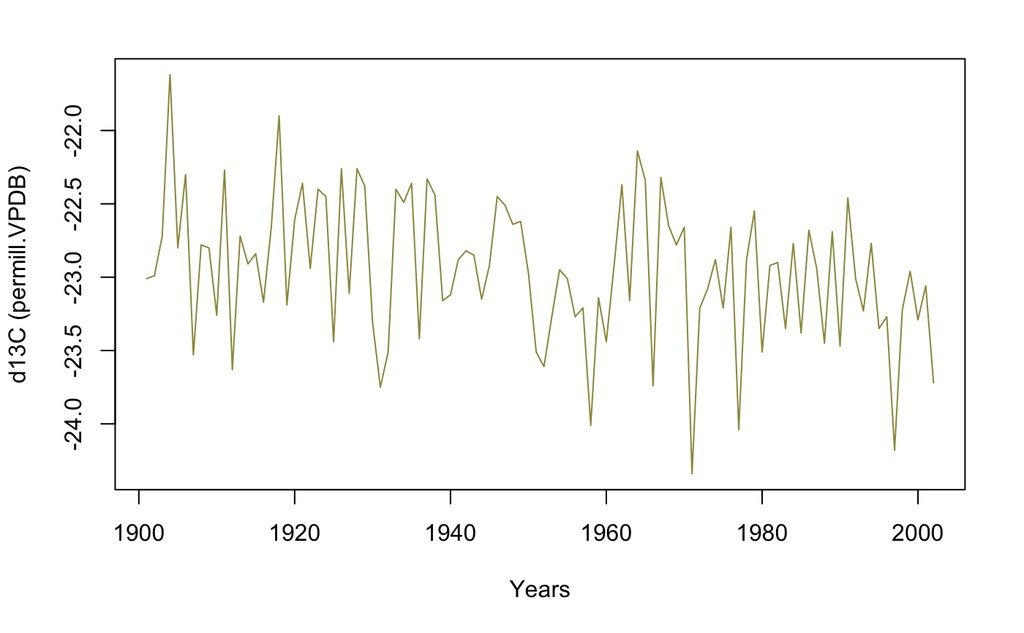

```r
# You will also need to ensure that the name of the file is correct.
TR13 <- read.table("LIL.txt", header=T)

#convert to a time-series object.
TR13.ts <- ts(TR13,start=1901, frequency=1)

#plot the raw data
ts.plot(TR13.ts,ylab="d13C (permill.VPDB)",xlab="Years", col="#9C964A")
```

Question 1: Observe the trend (directionality). What do you see?

Look more closely at various time windows:

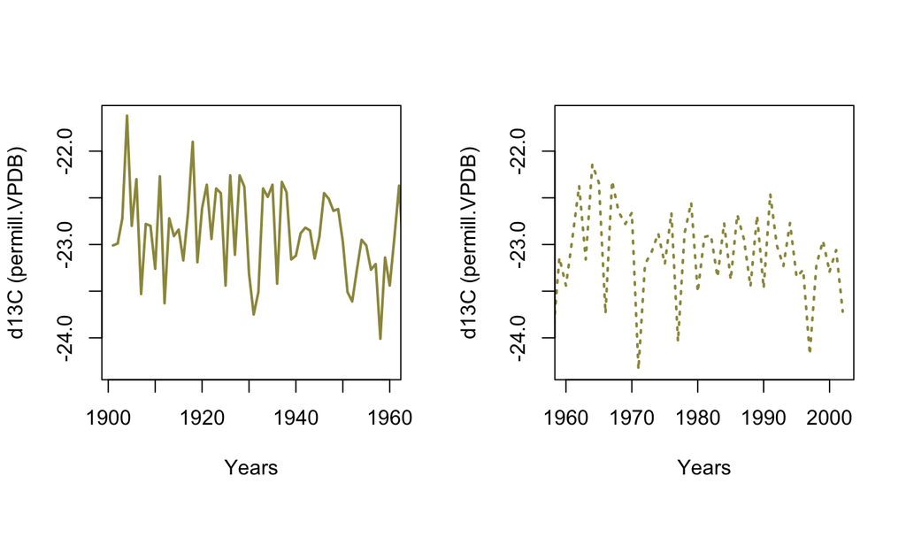

```r
layout(matrix(1:2,nrow = 1, ncol = 2,byrow = T), widths = c(3,3),heights = c(3,3),respect = TRUE)
ts.plot(TR13.ts,ylab="d13C (permill.VPDB)",xlab="Years",xlim=c(1901,1960), col="#9C964A",lty=1, lwd=2)
ts.plot(TR13.ts,ylab="d13C (permill.VPDB)",xlab="Years",xlim=c(1960,2002), col="#9C964A",lty=3,lwd=2)
```

Question 2: Do you observe a difference between various time windows?

Question 3: Describe the difference between various time windows?

Import the atmospheric d13C dataset:

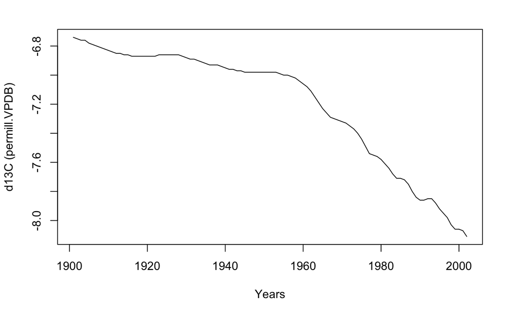

```r
ATM13 <- read.table("ATM13C.txt", header=T)

#convert to a time-series object
ATM13.ts <- ts(ATM13,start=1901,frequency=1)

#plot the atmospheric d13C dataset
ts.plot(ATM13.ts,ylab="d13C (permill.VPDB)",xlab="Years")
```

Question 4: Observe the trend (directionality) and interannual variability. What do you see?

```r
# plot the raw tree ring d13C dataset and the atmospheric d13C dataset
layout(matrix(1:2,nrow = 1, ncol = 2,byrow = T), widths = c(3,3),heights = c(3,3),respect = TRUE)
ts.plot(TR13.ts,ylab="d13C (permill.VPDB)",xlab="Years", col="#9C964A",main="TREE RINGS")
ts.plot(ATM13.ts,ylab="d13C (permill.VPDB)",xlab="Years", main="ATMOSPHERE")
```

[output not shown]

Question 5: Describe the difference between absolute tree ring and atmospheric d13C values. What drives this difference?

Question 6: Compare both trends (directionality, magnitude). Describe the similarities/differences.

## PART 2: Correcting Tree Ring 13C raw Data

### Suess Effect

As a consequence of industrialization, the isotopic composition of atmospheric CO2 has changed.  
This change corresponds to a decline in atmospheric d13C related to burning of fossil fuels (enriched in 12C and/or low in 13C). This trend or effect is termed Suess Effect (Keeling, 1979), is recorded in tree-ring raw d13C data, and should therefore be removed before analyzing climate or ecophysiology of a tree ring d13C chronology.

This correction can be made as follows:

```r
TR13.corr <- TR13.ts -(ATM13.ts + 6.5)

# the 6.5  corresponds to the  pre industrial atmospheric d13C value.
# the correction factor (ATM13.ts + 6.5) is applied to express tree-ring d13C values relative
# to a pre-industrial standard value of 6.5 permill i.e. remove the trend of 13C that result
# from a decline due to the Suess effect.
```

Add the corrected tree ring data to the plot with the raw data:

```r
ts.plot(TR13.ts,ylab="d13C (permill.VPDB)",xlab="Years", col="#9C964A", ylim=c(-24,-21))
lines (TR13.corr, col="#F21A00")
```

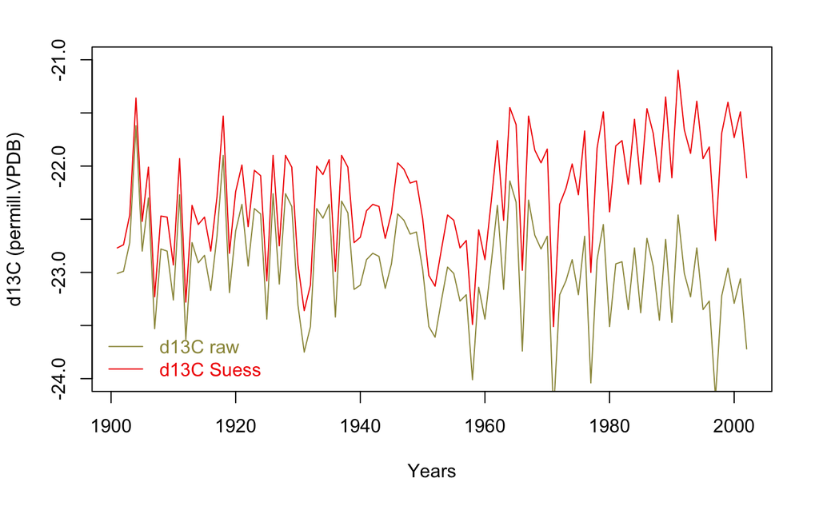

```r
legend("bottomleft",c("d13C raw", "d13C Suess"),lwd= c(1,1), bty = "n", col=c("#9C964A","#F21A00"),
       text.col=c("#9C964A","#F21A00"),ncol=1)
```

```r
# Note that you may need to adjust the limits of the Y axis to accommodate the values-range of raw and corrected 13C data. You can do that using ylim=c(,) to set min and max Y axis values.
```

Question 7: How does the corrected d13C compare to the raw d13C.